# Data visualization principles

# 11 Data visualization principles

Here, we aim to provide some general principles we can use as a guide for effective data visualization. We compare and contrast plots that follow these principles to those that don’t. The principles are mostly based on research related to how humans detect patterns and make visual comparisons. When deciding on a visualization approach, it is also important to keep our goal in mind.

We will use:

```r
library(tidyverse)
library(dslabs)
library(gridExtra)
```

## 11.1 Encoding data using visual cues

We start by describing some principles for encoding data. There are several approaches at our disposal including position, aligned lengths, angles, area, brightness, and color hue. A widely used graphical representation of percentages is the pie chart. The donut chart is an example of a plot that uses only area. In this case, simply showing the numbers is clearer. The barplot uses this approach by using bars of length proportional to the quantities of interest. In general, when displaying quantities, position and length are preferred over angles and/or area.

## 11.3 Do not distort quantities

If you plot a data by circle with radius in proportion to that. It will distort your data. Not surprisingly, ggplot2 defaults to using area rather than radius.

## 11.4 Order categories by a meaningful value

When one of the axes is used to show categories, as is done in barplots, the default ggplot2 behavior is to order the categories alphabetically. Instead, we should order by a meaningful quantity. We previously learned how to use the `reorder` function, which helps us achieve this goal.

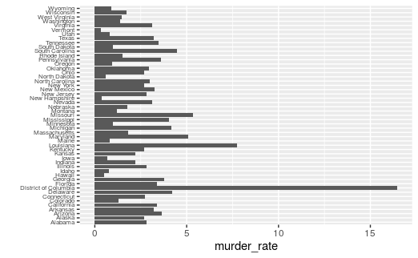

```r
data(murders)
murders %>% mutate(murder_rate = total / population * 100000) %>%
#  mutate(state = reorder(state, murder_rate)) %>%
  ggplot(aes(state, murder_rate)) +
  geom_bar(stat="identity") +
  coord_flip() +
  theme(axis.text.y = element_text(size = 6)) +
  xlab("")
```

```
data("gapminder")
gapminder %>% filter(year == 2016) %>%
  group_by(region) %>%
  mutate(dollars_per_day = gdp/365) %>%
  ggplot(aes(region, dollars_per_day)) +
  labs(aes(region)) +
  geom_boxplot() +
  geom_point()
```

## 11.5 Show the data

We have focused on displaying single quantities across categories. We now shift our attention to displaying data, with a focus on comparing groups. This time let’s assume that we are interested in the difference in heights between males and females. This simple ggplot2 code already generates a more informative plot than the barplot by simply showing all the data points:

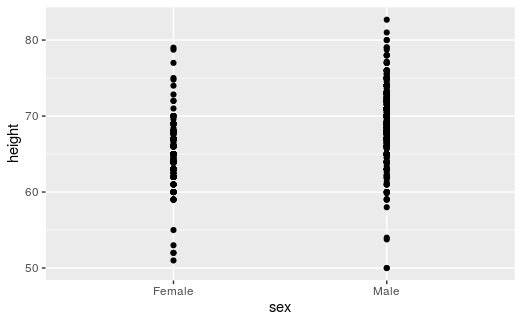

```r
data(heights)

heights %>%
  ggplot(aes(sex, height)) +
  geom_point()
```

This plot has limitations as well, since we can’t really see all the 238 and 812 points plotted for females and males respectively, and many points are plotted on top of each other. The first is to add jitter. This adds a small random shift to each point. And the second improvement comes from using alpha blending. That makes the dot transparent.

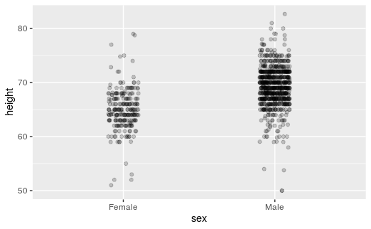

```r
heights %>%
  ggplot(aes(sex, height)) +
  geom_jitter(width = 0.1, alpha = 0.2)
```

## 11.6 Ease comparisons

### 11.6.1 Use common axes

Since there are so many points, it is more effective to show distributions rather than individual points.

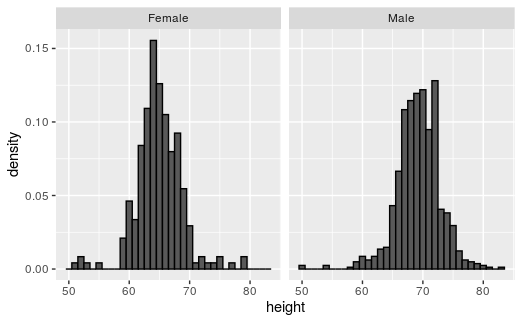

```r
heights %>% group_by(sex) %>%
  ggplot(aes(height, y= ..density..)) +
  geom_histogram(binwidth = 1, color = 'black') +
  facet_grid(.~sex)
```

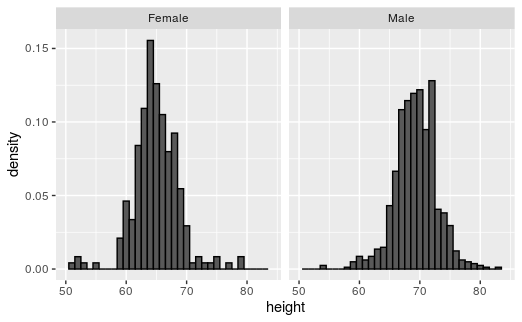

```r
heights %>% group_by(sex) %>%
  ggplot(aes(height, y= ..density..)) +
  geom_histogram(binwidth = 1, color = 'black') +
  xlim(50, 84) +
  facet_grid(.~sex)
```

### 11.6.2 Align plots vertically to see horizontal changes and horizontally to see vertical changes

Aligning the plots vertically helps us see this change when the axes are fixed:

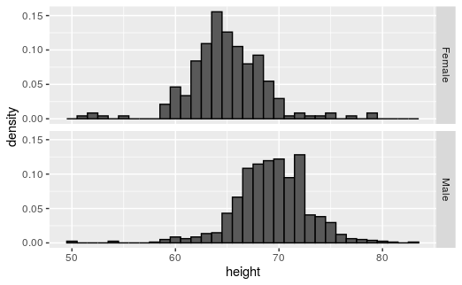

```r
heights %>%
  ggplot(aes(height, ..density..)) +
  geom_histogram(binwidth = 1, color="black") +
  facet_grid(sex~.)
```

If we want the more compact summary provided by boxplots, we then align them horizontally

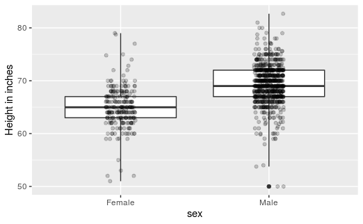

```r
 heights %>%
  ggplot(aes(sex, height)) +
  geom_boxplot(coef=3) +
  geom_jitter(width = 0.1, alpha = 0.2) +
  ylab("Height in inches")
```

### 11.6.3 Consider transformations

The combination of an incorrectly chosen barplot and a failure to use a log transformation when one is merited can be particularly distorting. For example, the average of the population by each continent. If we use log scale, it is likely that we may distort the data. So, we must carefully deal with it.

### 11.6.4 Visual cues to be compared should be adjacent

If we compare multiple plots, the order of any labels must be identical.

## 11.7 11.7 Think of the color blind

About 10% of the population is color blind. Unfortunately, the default colors used in ggplot2 are not optimal for this group. However, ggplot2 does make it easy to change the color palette used in the plots.

```r
color_blind_friendly_cols <-
  c("#999999", "#E69F00", "#56B4E9", "#009E73",
    "#F0E442", "#0072B2", "#D55E00", "#CC79A7")
```

## 11.8 Plots for two variables

In general, you should use scatterplots to visualize the relationship between two variables. However, there are some exceptions and we describe two alternative plots here: the slope chart and the Bland-Altman plot.

### 11.8.1 Slope charts

One exception where another type of plot may be more informative is when you are comparing variables of the same type. There is no geometry for slope charts in ggplot2, but we can construct one using `geom_line`.

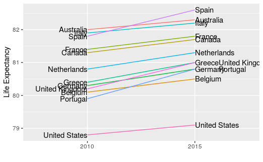

```r
# select regions/countries we want
west <- c("Western Europe","Northern Europe","Southern Europe",
          "Northern America","Australia and New Zealand")

# get data of life expectancy of selected countries of two year
dat <- gapminder %>%
  filter(year%in% c(2010, 2015) & region %in% west &
           !is.na(life_expectancy) & population > 10^7)


dat %>%
  # set location of each point
  mutate(location = ifelse(year == 2010, 1, 2),
         location = ifelse(year == 2015 &
                             country %in% c("United Kingdom","Portugal"),
                           location+0.22, location),
         #
         hjust = ifelse(year == 2010, 1, 0)) %>%
  mutate(year = as.factor(year)) %>%
  ggplot(aes(year, life_expectancy, group = country)) +
  # make lines connecting same country
  geom_line(aes(color = country), show.legend = FALSE) +
  # show texts
  geom_text(aes(x = location, label = country, hjust = hjust),
            show.legend = FALSE) +
  xlab("") +
  ylab("Life Expectancy")
```

If we use scatter plots, we should observe the rules. But we cannot see data at once.

### 11.8.2 Bland-Altman plot

The Bland-Altman plot, also known as the Tukey mean-difference plot and the MA-plot, shows the difference versus the average:

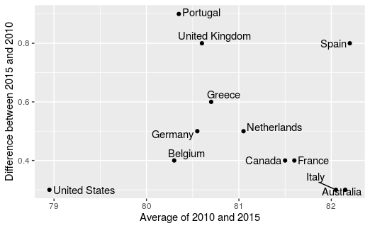

```r
library(ggrepel)

dat %>%
  # make colunm of data we want
  mutate(year = paste0("life_expectancy_", year)) %>%
  select(country, year, life_expectancy) %>%
  spread(year, life_expectancy) %>%
  # calculate avg. and dif.
  mutate(average = (life_expectancy_2015 + life_expectancy_2010)/2,
         difference = life_expectancy_2015 - life_expectancy_2010) %>%

  # plotting
  ggplot(aes(average, difference, label = country)) +
  geom_point() +

  # name the point and axis
  geom_text_repel() +
  geom_abline(lty = 2) +
  xlab("Average of 2010 and 2015") +
  ylab("Difference between 2015 and 2010")
```

## 11.9 Encoding a third variable

We can use other variables like shape wiht argument `shape` or colors with package `RColorBrewer`

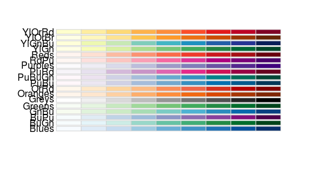

```r
library(RColorBrewer)
display.brewer.all(type="seq")
```

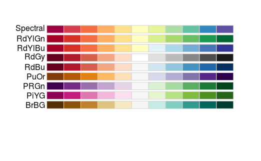

```r
display.brewer.all(type="div")
```

## 11.10 Avoid pseudo-three-dimensional plots

Humans are not good at seeing in three dimensions and our limitation is even worse with regard to pseudo-three-dimensions. This only adds confusion and makes it harder to relay your message.

## 11.11 Avoid too many significant digits

By default, statistical software like R returns many significant digits. That many digits often adds no information and the added the visual clutter can make it hard for the viewer to understand the message.

## 11.12 Know your audience

Graphs can be used for 1) our own exploratory data analysis, 2) to convey a message to experts, or 3) to help tell a story to a general audience. Make sure that the intended audience understands each element of the plot.

## 11.13 Exercises

For these exercises, we will be using the vaccines data in the dslabs package:

```r
library(tidyverse)
library(dslabs)
library(ggplot2)
data(us_contagious_diseases)
```

1. Pie charts are appropriate: A

A. When we want to display percentages. -> Yes.

B. When ggplot2 is not available. -> The platform does not matter.

C. When I am in a bakery. -> …?

D. Never. Barplots and tables are always better. -> Maybe? But always there is exceptions.

B. The axis does not start at 0. Judging by the length, it appears Trump received 3 times as many votes when, in fact, it was about 30% more. -> Exactly.

C. The colors should be the same. -> I think it is more desirable to differentiate each candidate.

D. Percentages should be shown as a pie chart. -> We do not need percenatage data.

A. They provide the same information, so they are both equally as good. -> Nope.

B. The plot on the right is better because it orders the states alphabetically. -> Alphabetic order is left one.

C. The plot on the right is better because alphabetical order has nothing to do with the disease and by ordering according to actual rate, we quickly see the states with most and least rates. -> Correct.

D. Both plots should be a pie chart. -> No way…

4. To make the plot on the left, we have to reorder the levels of the states’ variables.

```r
dat <- us_contagious_diseases %>%
  filter(year == 1967 & disease=="Measles" & !is.na(population)) %>%
  mutate(rate = count / population * 10000 * 52 / weeks_reporting)
```

Note what happens when we make a barplot:

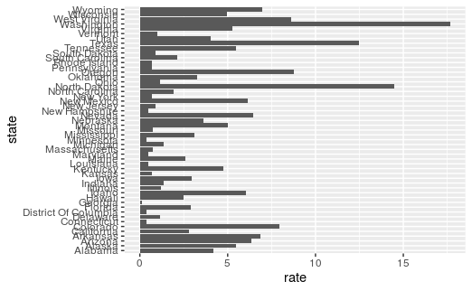

```r
dat %>% ggplot(aes(state, rate)) +
  geom_bar(stat="identity") +
  coord_flip()
```

Define these objects:

```r
state <- dat$state
rate <- dat$count/dat$population*10000*52/dat$weeks_reporting
```

Redefine the `state` object so that the levels are re-ordered. Print the new object `state` and its levels so you can see that the vector is not re-ordered by the levels.

```r
state <- reorder(state, rate)
state
```

```
 [1] Alabama              Alaska
 [3] Arizona              Arkansas
 [5] California           Colorado
 [7] Connecticut          Delaware
 [9] District Of Columbia Florida
[11] Georgia              Hawaii
[13] Idaho                Illinois
[15] Indiana              Iowa
[17] Kansas               Kentucky
[19] Louisiana            Maine
[21] Maryland             Massachusetts
[23] Michigan             Minnesota
[25] Mississippi          Missouri
[27] Montana              Nebraska
[29] Nevada               New Hampshire
[31] New Jersey           New Mexico
[33] New York             North Carolina
[35] North Dakota         Ohio
[37] Oklahoma             Oregon
[39] Pennsylvania         Rhode Island
[41] South Carolina       South Dakota
[43] Tennessee            Texas
[45] Utah                 Vermont
[47] Virginia             Washington
[49] West Virginia        Wisconsin
[51] Wyoming
attr(,"scores")
             Alabama               Alaska              Arizona
          4.16107582           5.46389893           6.32695891
            Arkansas           California             Colorado
          6.87899954           2.79313560           7.96331905
         Connecticut             Delaware District Of Columbia
          0.36986840           1.13098183           0.35873614
             Florida              Georgia               Hawaii
          2.89358806           0.09987991           2.50173748
               Idaho             Illinois              Indiana
          6.03115170           1.20115480           1.34027323
                Iowa               Kansas             Kentucky
          2.94948911           0.66386422           4.74576011
           Louisiana                Maine             Maryland
          0.46088071           2.57520433           0.49922233
       Massachusetts             Michigan            Minnesota
          0.74762338           1.33466700           0.37722410
         Mississippi             Missouri              Montana
          3.11366532           0.75696354           5.00433320
            Nebraska               Nevada        New Hampshire
          3.64389801           6.43683882           0.47181511
          New Jersey           New Mexico             New York
          0.88414264           6.15969926           0.66849058
      North Carolina         North Dakota                 Ohio
          1.92529764          14.48024642           1.16382241
            Oklahoma               Oregon         Pennsylvania
          3.27496900           8.75036439           0.67687303
        Rhode Island       South Carolina         South Dakota
          0.68207448           2.10412531           0.90289534
           Tennessee                Texas                 Utah
          5.47344506          12.49773953           4.03005836
             Vermont             Virginia           Washington
          1.00970314           5.28270939          17.65180349
       West Virginia            Wisconsin              Wyoming
          8.59456463           4.96246019           6.97303449
51 Levels: Georgia District Of Columbia Connecticut ... Washington
```

```r
levels(state)
```

```
 [1] "Georgia"              "District Of Columbia"
 [3] "Connecticut"          "Minnesota"
 [5] "Louisiana"            "New Hampshire"
 [7] "Maryland"             "Kansas"
 [9] "New York"             "Pennsylvania"
[11] "Rhode Island"         "Massachusetts"
[13] "Missouri"             "New Jersey"
[15] "South Dakota"         "Vermont"
[17] "Delaware"             "Ohio"
[19] "Illinois"             "Michigan"
[21] "Indiana"              "North Carolina"
[23] "South Carolina"       "Hawaii"
[25] "Maine"                "California"
[27] "Florida"              "Iowa"
[29] "Mississippi"          "Oklahoma"
[31] "Nebraska"             "Utah"
[33] "Alabama"              "Kentucky"
[35] "Wisconsin"            "Montana"
[37] "Virginia"             "Alaska"
[39] "Tennessee"            "Idaho"
[41] "New Mexico"           "Arizona"
[43] "Nevada"               "Arkansas"
[45] "Wyoming"              "Colorado"
[47] "West Virginia"        "Oregon"
[49] "Texas"                "North Dakota"
[51] "Washington"
```

5. Now with one line of code, define the `dat` table as done above, but change the use mutate to create a rate variable and reorder the state variable so that the levels are reordered by this variable. Then make a barplot using the code above, but for this new `dat`.

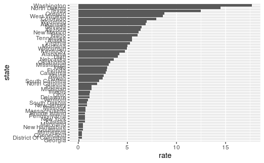

```r
dat <- us_contagious_diseases %>%
  filter(year == 1967 & disease == "Measles" & !is.na(population)) %>%
  mutate(rate = count / population * 10000 * 52 / weeks_reporting) %>%
  mutate(state = reorder(state, rate))

dat %>% ggplot(aes(state, rate)) +
  geom_bar(stat="identity") +
  coord_flip()
```

6. Say we are interested in comparing gun homicide rates across regions of the US. We see this plot:

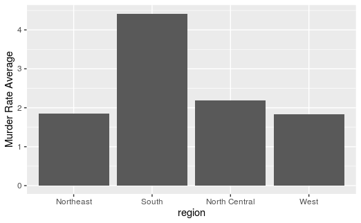

```r
library(dslabs)
data("murders")
murders %>% mutate(rate = total/population*100000) %>%
  group_by(region) %>%
  summarize(avg = mean(rate)) %>%
  mutate(region = factor(region)) %>%
  ggplot(aes(region, avg)) +
  geom_bar(stat="identity") +
  ylab("Murder Rate Average")
```

and decide to move to a state in the western region. What is the main problem with this interpretation? C

A. The categories are ordered alphabetically. -> It does not matter.

B. The graph does not show standard errors. -> Do we need it? I do not think so.

C. It does not show all the data. We do not see the variability within a region and it’s possible that the safest states are not in the West. -> Correct.

D. The Northeast has the lowest average. -> Who cares?

7. Make a boxplot of the murder rates defined as

```r
data("murders")
murders %>% mutate(rate = total/population*100000)
```

| state | abb | region | population | total | rate |
| --- | --- | --- | --- | --- | --- |
| Alabama | AL | South | 4779736 | 135 | 2.8244238 |
| Alaska | AK | West | 710231 | 19 | 2.6751860 |
| Arizona | AZ | West | 6392017 | 232 | 3.6295273 |
| Arkansas | AR | South | 2915918 | 93 | 3.1893901 |
| California | CA | West | 37253956 | 1257 | 3.3741383 |
| Colorado | CO | West | 5029196 | 65 | 1.2924531 |
| Connecticut | CT | Northeast | 3574097 | 97 | 2.7139722 |
| Delaware | DE | South | 897934 | 38 | 4.2319369 |
| District of Columbia | DC | South | 601723 | 99 | 16.4527532 |
| Florida | FL | South | 19687653 | 669 | 3.3980688 |

[output cut: 41 more lines]

by region, showing all the points and ordering the regions by their median rate.

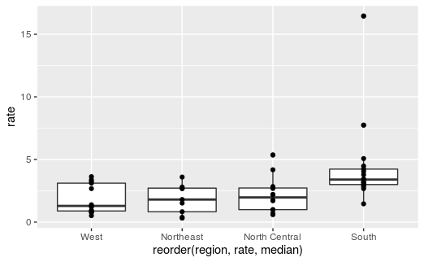

```r
murders %>%
  mutate(rate = total/population*100000) %>%
  group_by(region) %>%
  ggplot(aes(x = reorder(region, rate, median), y = rate)) +
  geom_boxplot() +
  geom_point()
```

Why is this happening? A

A. Humans are not good at reading pseudo-3D plots. -> Right

B. There must be an error in the code. -> ?

C. The colors confuse us. -> Nope.

D. Scatterplots should not be used to compare two variables when we have access to 3. -> When we use color, scatterplots are also good geometry for comparisions.

## 11.14 Case study: impact of vaccines on battling infectious diseases

Vaccines have helped save millions of lives. In the 19th century, before herd immunization was achieved through vaccination programs, deaths from infectious diseases, such as smallpox and polio, were common. However, today vaccination programs have become somewhat controversial despite all the scientific evidence for their importance. The data used for these plots were collected, organized and distributed by the Tycho Project. They include weekly reported counts for seven diseases from 1928 to 2011, from all fifty states. We include the yearly totals in the dslabs package:

```r
library(tidyverse)
library(dslabs)
data(us_contagious_diseases)
str(us_contagious_diseases)
```

```
'data.frame':   18870 obs. of  6 variables:
 $ disease        : Factor w/ 7 levels "Hepatitis A",..: 1 1 1 1 1 1 1 1 1 1 ...
 $ state          : Factor w/ 51 levels "Alabama","Alaska",..: 1 1 1 1 1 1 1 1 1 1 ...
 $ year           : num  1966 1967 1968 1969 1970 ...
 $ weeks_reporting: int  50 49 52 49 51 51 45 45 45 46 ...
 $ count          : num  321 291 314 380 413 378 342 467 244 286 ...
 $ population     : num  3345787 3364130 3386068 3412450 3444165 ...
```

We create a temporary object `dat`:

```r
# Select Measles only
the_disease <- "Measles"

# Calculate incident rate per 100000
dat <- us_contagious_diseases %>%
  filter(!state%in%c("Hawaii","Alaska") & disease == the_disease) %>%
  mutate(rate = count / population * 10000 * 52 / weeks_reporting) %>%
  mutate(state = reorder(state, rate))
```

We can now easily plot disease rates per year. Here are the measles data from California:

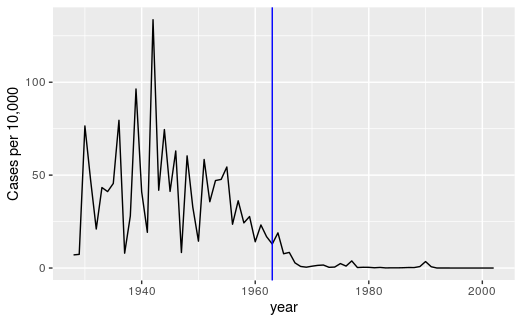

```r
dat %>%
  # select data of California
  filter(state == "California" & !is.na(rate)) %>%
  ggplot(aes(year, rate)) +
  geom_line() +
  ylab("Cases per 10,000")  +
  # insert the time when vaccine was introduced
  geom_vline(xintercept=1963, col = "blue")
```

Now can we show data for all states in one plot? We have three variables to show: year, state and rate. We use the geometry `geom_tile` to tile the region with colors representing disease rates.

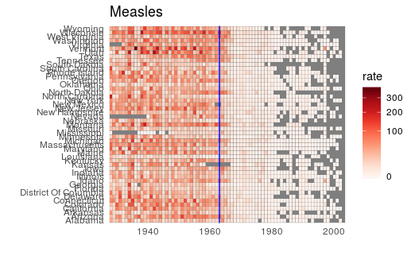

```r
dat %>% ggplot(aes(year, state, fill = rate)) +
  geom_tile(color = "grey50") +
  scale_x_continuous(expand=c(0,0)) +
  scale_fill_gradientn(colors = RColorBrewer::brewer.pal(9, "Reds"), trans = "sqrt") +
  geom_vline(xintercept=1963, col = "blue") +
  # make more tidy
  theme_minimal() +  theme(panel.grid = element_blank()) +
  ggtitle(the_disease) +
  ylab("") +
  xlab("")
```

This plot makes a very striking argument for the contribution of vaccines. However, one limitation of this plot is that it uses color to represent quantity. If we are willing to lose state information, we can make a version of the plot that shows the values with position.

```r
avg <- us_contagious_diseases %>%
  filter(disease==the_disease) %>% group_by(year) %>%
  summarize(us_rate = sum(count, na.rm=TRUE)/sum(population, na.rm=TRUE)*10000)
```

Now to make the plot we simply use the geom_line geometry:

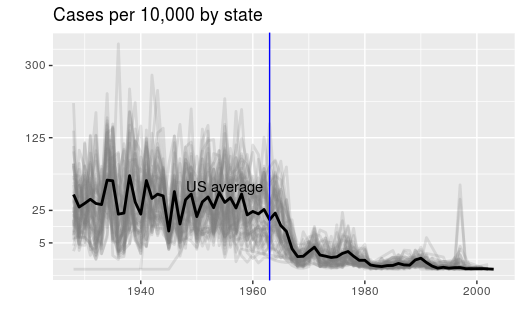

```r
dat %>%
  filter(!is.na(rate)) %>%
    ggplot() +
  geom_line(aes(year, rate, group = state),  color = "grey50",
            show.legend = FALSE, alpha = 0.2, size = 1) +
  geom_line(mapping = aes(year, us_rate),  data = avg, size = 1, color = "black") +
  scale_y_continuous(trans = "sqrt", breaks = c(5, 25, 125, 300)) +
  ggtitle("Cases per 10,000 by state") +
  xlab("") +
  ylab("") +
  geom_text(data = data.frame(x = 1955, y = 50),
            mapping = aes(x, y, label="US average"),
            color="black") +
  geom_vline(xintercept=1963, col = "blue")
```

## 11.15 Exercises

1. Reproduce the image plot we previously made but for smallpox. For this plot, do not include years in which cases were not reported in 10 or more weeks.

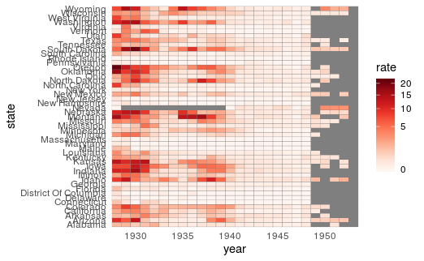

```r
dat <- us_contagious_diseases %>%
  filter(disease == "Smallpox" & !is.na(population)) %>%
  mutate(rate = count / population * 10000 * 52 / weeks_reporting)

dat %>% ggplot(aes(year, state, fill = rate)) +
  geom_tile(color = "grey50") +
  scale_x_continuous(expand=c(0,0)) +
  scale_fill_gradientn(colors = RColorBrewer::brewer.pal(9, "Reds"), trans = "sqrt") +
  theme_minimal() +  theme(panel.grid = element_blank())
```

```r
NA
```

2. Now reproduce the time series plot we previously made, but this time following the instructions of the previous question.

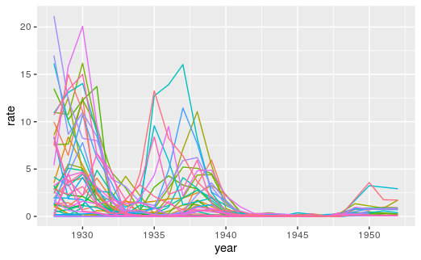

```r
dat %>% filter(!is.na(rate)) %>%
  group_by(state) %>%
  ggplot(aes(year, rate)) +
  geom_line(aes(color = state), show.legend = FALSE)
```

3. For the state of California, make a time series plots showing rates for all diseases. Include only years with 10 or more weeks reporting. Use a different color for each disease.

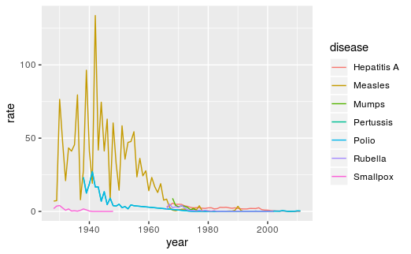

```r
dat <- us_contagious_diseases %>%
  filter(state == 'California' & !is.na(population)) %>%
  mutate(rate = count / population * 10000 * 52 / weeks_reporting)

dat %>%
  filter(!(weeks_reporting < 9)) %>%
  group_by(disease) %>%
  ggplot(aes(year, rate, color = disease)) +
  geom_line()
```

4. Now do the same for the rates for the US. Hint: compute the US rate by using summarize, the total divided by total population.

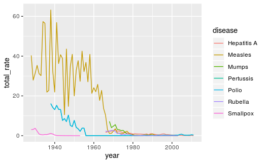

```r
us_contagious_diseases %>%
  group_by(disease, year) %>%
  summarize(total_rate = sum(count, na.rm = TRUE) / sum(population, na.rm = TRUE) * 10000) %>%
  ggplot(aes(year, total_rate, color = disease)) +
  geom_line()
```